### Interesting Findings

##### No relationship between the difference compensation rates. Would have expected a multiplicative relationship between DailyRate and Hourly Rate, or Daily Rate and Monthly Rate, etc.

##### Observaton:

##### Strong Correlation between observation incoming order and employee number

##### Number of Companies Worked

```r
summary(noattrit$NumCompaniesWorked)
```

```
##    Min. 1st Qu.  Median    Mean 3rd Qu.    Max.
##   0.000   1.000   2.000   2.646   4.000   9.000
```

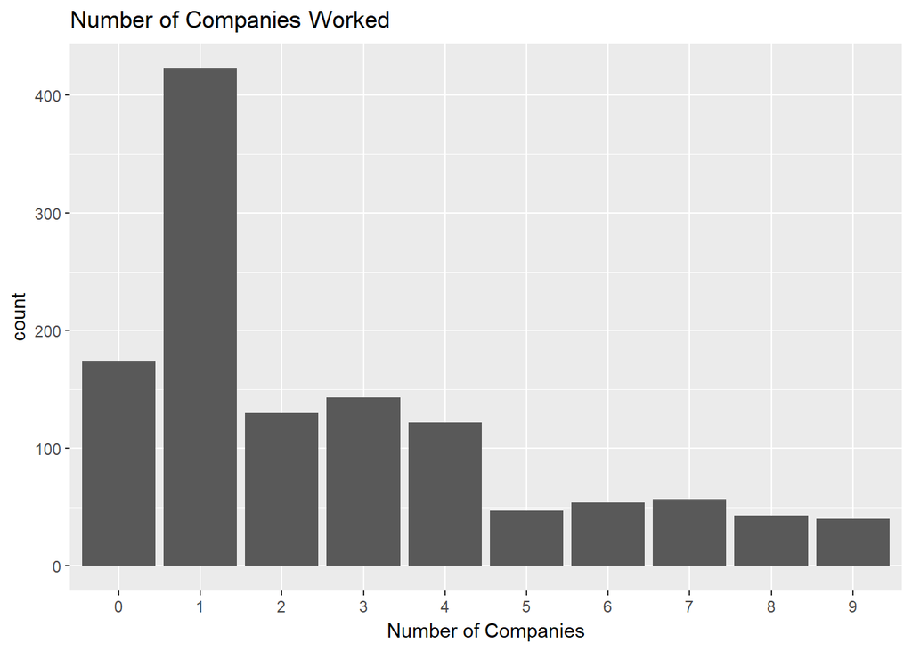

```r
ggplot(data=noattrit, aes(x=factor(noattrit$NumCompaniesWorked))) + geom_histogram(stat="count",position = "dodge") +xlab("Number CompaniesWorked") + scale_x_discrete(name='Number of Companies') +ggtitle("Number of Companies Worked")
```

#### Compensation Rates - No correlations

##### Monthly Income vs Monthly Rate

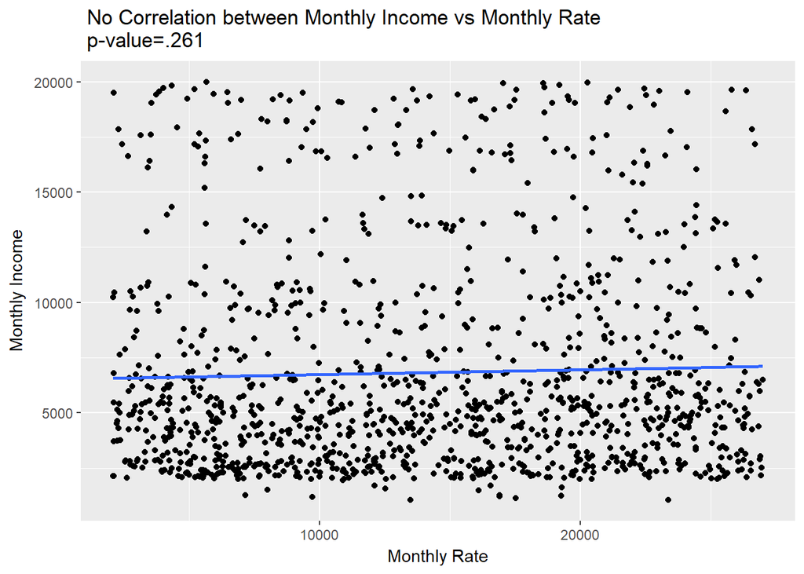

```r
ggplot(data=noattrit,aes(x=noattrit$MonthlyRate, y=noattrit$MonthlyIncome)) +
geom_point()  + ggtitle(" No Correlation between Monthly Income vs Monthly Rate \n p-value=.261") + xlab("Monthly Rate")+ylab("Monthly Income") + stat_smooth(method="lm", se=FALSE)
```

```r
result <- lm(noattrit$MonthlyIncome ~ noattrit$MonthlyRate)
summary(result)
```

```
##
## Call:
## lm(formula = noattrit$MonthlyIncome ~ noattrit$MonthlyRate)
##
## Residuals:
##    Min     1Q Median     3Q    Max
##  -5979  -3597  -1645   1986  13353
##
## Coefficients:
##                       Estimate Std. Error t value Pr(>|t|)
## (Intercept)          6.522e+03  3.079e+02  21.180   <2e-16 ***
## noattrit$MonthlyRate 2.175e-02  1.933e-02   1.126    0.261
## ---
## Signif. codes:  0 '***' 0.001 '**' 0.01 '*' 0.05 '.' 0.1 ' ' 1
##
## Residual standard error: 4818 on 1231 degrees of freedom
## Multiple R-squared:  0.001028,   Adjusted R-squared:  0.0002168
## F-statistic: 1.267 on 1 and 1231 DF,  p-value: 0.2605
```

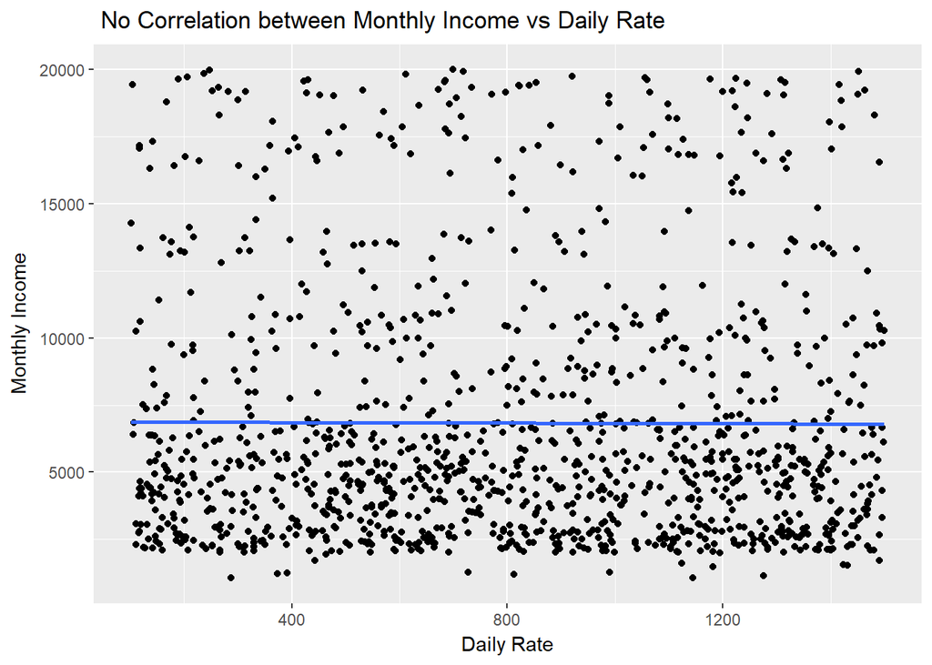

```r
ggplot(data=noattrit,aes(x=noattrit$DailyRate, y=noattrit$MonthlyIncome)) +
geom_point()  + ggtitle(" No Correlation between Monthly Income vs Daily Rate") + xlab("Daily Rate")+ylab("Monthly Income") + stat_smooth(method="lm", se=FALSE)
```

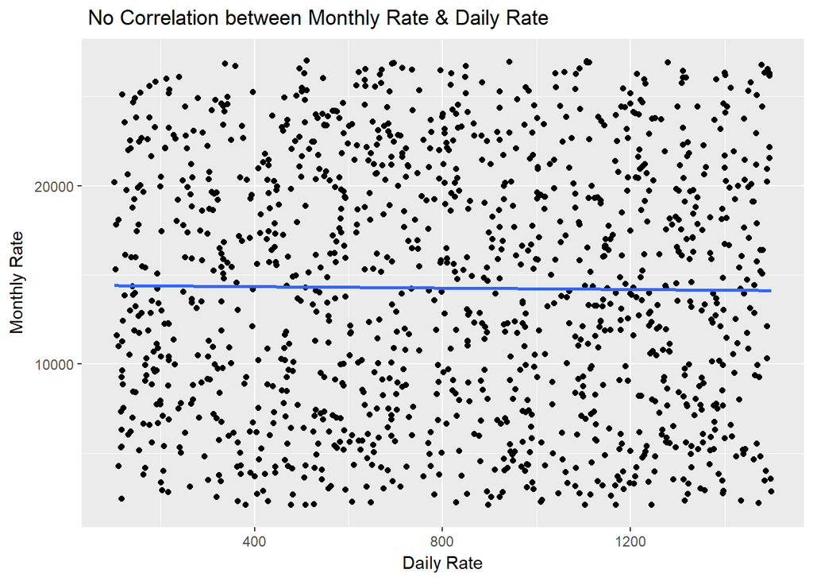

```r
ggplot(data=noattrit,aes(x=noattrit$DailyRate, y=noattrit$MonthlyRate)) +
geom_point()  + ggtitle(" No Correlation between Monthly Rate & Daily Rate") + xlab("Daily Rate")+ylab("Monthly Rate") + stat_smooth(method="lm", se=FALSE)
```

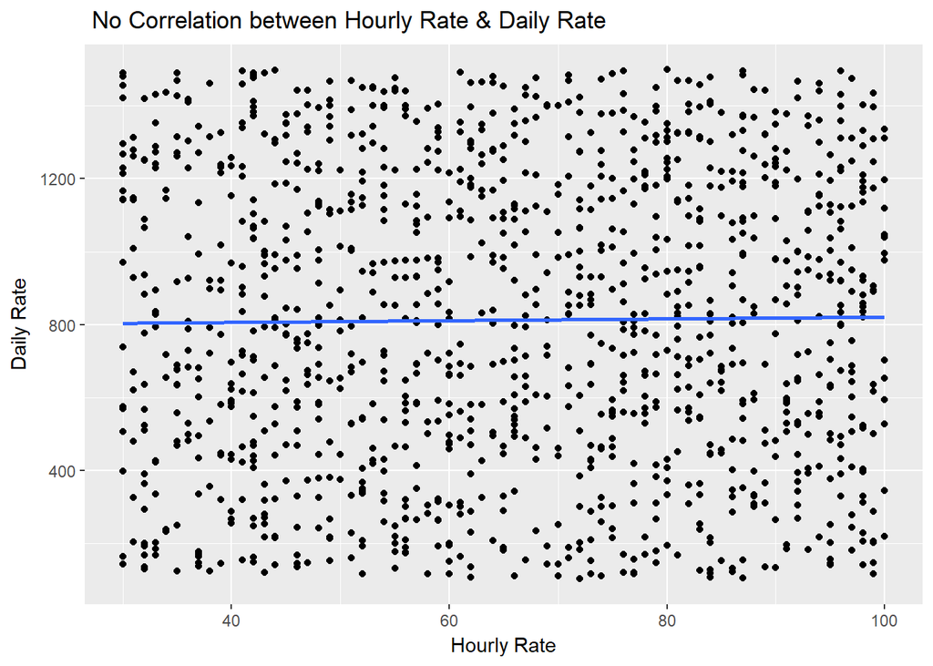

```r
ggplot(data=noattrit,aes(x=noattrit$HourlyRate, y=noattrit$DailyRate)) +
geom_point()  + ggtitle(" No Correlation between Hourly Rate & Daily Rate") + xlab("Hourly Rate")+ylab("Daily Rate") + stat_smooth(method="lm", se=FALSE)
```

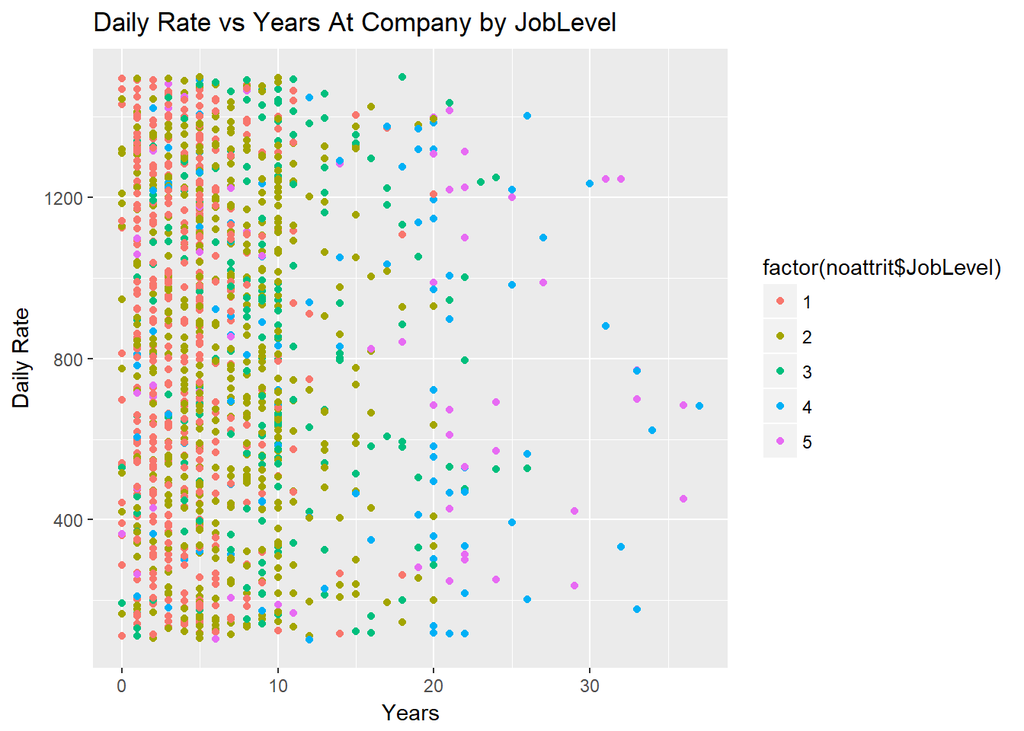

```r
ggplot(data=noattrit,aes(x=noattrit$YearsAtCompany, y=noattrit$DailyRate,col=factor(noattrit$JobLevel))) +
geom_point()  + ggtitle("Daily Rate vs Years At Company by JobLevel") + xlab("Years")+ylab("Daily Rate")
```

#### The strong correlations found between TimeAtCompany & Total Working Time with Monthly Income are not evident with DailyRate, Hourly Rate nor Monthly Rate.

#### Attempted to determine relationships using log-log, linear-log, log-linear transformations and multiplicative models.

### Experimentation

1.Employee Number - a recoded start date?….No 2.Linear Regression Modeling to id first order variables to differentiate factor variables

##### Employee Number is strongly correlated to the index number of the incoming data. Perhaps the employee number is a time ordered variable related to employee start date?

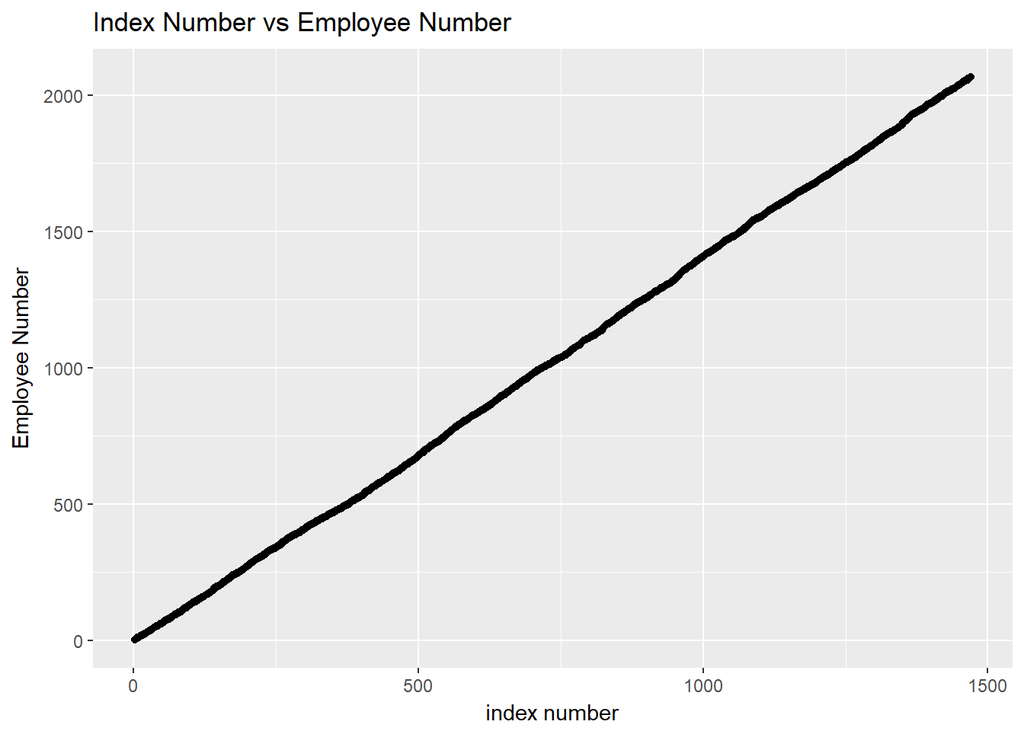

```r
ggplot(data=noattrit,aes(x=as.integer(rownames(noattrit)), y=noattrit$EmployeeNumber)) +
geom_point() + ggtitle("Index Number vs Employee Number") + ylab("Employee Number")+ xlab("index number")
```

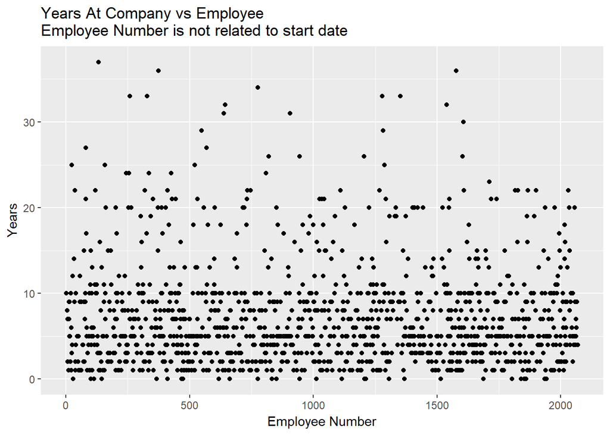

```r
ggplot(data=noattrit,aes(x=noattrit$EmployeeNumber, y=noattrit$YearsAtCompany)) +
geom_point()  + ggtitle("Years At Company vs Employee \nEmployee Number is not related to start date") + xlab("Employee Number")+ylab("Years")
```

#### Used Linear Regression Modeling to determine variables of significance between Job Roles

#### Important first order terms in the model are: EducationField,Age,JobLevel,MonthlyIncome, Gender, JobInvolvement,NumCompaniesWorked,YearsAtCompany,YearsWithCurrManager

```r
options(width = 150)

#Run a linear regression model using all variables to id the important first order terms
jr.lm <- lm(noattrit$JRCode ~ noattrit$BusinessTravel+ noattrit$EducationField+ noattrit$Gender+ noattrit$OverTime+ noattrit$MaritalStatus+ noattrit$Age+ noattrit$DailyRate+
noattrit$DistanceFromHome+ noattrit$Education+ noattrit$EmployeeNumber+noattrit$EnvironmentSatisfaction+ noattrit$HourlyRate+ noattrit$JobInvolvement+ noattrit$JobLevel+ noattrit$JobSatisfaction+
 noattrit$MonthlyIncome+ noattrit$MonthlyRate+ noattrit$NumCompaniesWorked+ noattrit$PercentSalaryHike+ noattrit$PerformanceRating+ noattrit$RelationshipSatisfaction+ noattrit$StockOptionLevel+
noattrit$TotalWorkingYears+ noattrit$TrainingTimesLastYear+ noattrit$WorkLifeBalance+ noattrit$YearsAtCompany+ noattrit$YearsInCurrentRole+ noattrit$YearsSinceLastPromotion+ noattrit$YearsWithCurrManager)
summary(jr.lm)
```

```
##
## Call:
## lm(formula = noattrit$JRCode ~ noattrit$BusinessTravel + noattrit$EducationField +
##     noattrit$Gender + noattrit$OverTime + noattrit$MaritalStatus +
##     noattrit$Age + noattrit$DailyRate + noattrit$DistanceFromHome +
##     noattrit$Education + noattrit$EmployeeNumber + noattrit$EnvironmentSatisfaction +
##     noattrit$HourlyRate + noattrit$JobInvolvement + noattrit$JobLevel +
##     noattrit$JobSatisfaction + noattrit$MonthlyIncome + noattrit$MonthlyRate +
##     noattrit$NumCompaniesWorked + noattrit$PercentSalaryHike +
##     noattrit$PerformanceRating + noattrit$RelationshipSatisfaction +
##     noattrit$StockOptionLevel + noattrit$TotalWorkingYears +
##     noattrit$TrainingTimesLastYear + noattrit$WorkLifeBalance +
##     noattrit$YearsAtCompany + noattrit$YearsInCurrentRole + noattrit$YearsSinceLastPromotion +
##     noattrit$YearsWithCurrManager)
##
## Residuals:
##     Min      1Q  Median      3Q     Max
## -5.5355 -1.6075 -0.1949  1.8112  4.7772
##
## Coefficients:
##                                            Estimate Std. Error t value Pr(>|t|)
## (Intercept)                               4.410e+00  1.087e+00   4.056 5.33e-05 ***
## noattrit$BusinessTravelTravel_Frequently -1.847e-01  2.466e-01  -0.749  0.45416
## noattrit$BusinessTravelTravel_Rarely     -9.590e-02  2.067e-01  -0.464  0.64281
## noattrit$EducationFieldLife Sciences      1.170e+00  5.093e-01   2.297  0.02180 *
## noattrit$EducationFieldMarketing          2.600e+00  5.437e-01   4.782 1.95e-06 ***
## noattrit$EducationFieldMedical            1.083e+00  5.123e-01   2.114  0.03469 *
## noattrit$EducationFieldOther              1.002e+00  5.646e-01   1.774  0.07633 .
## noattrit$EducationFieldTechnical Degree   1.435e+00  5.486e-01   2.616  0.00901 **
## noattrit$GenderMale                      -2.214e-01  1.319e-01  -1.678  0.09361 .
## noattrit$OverTimeYes                     -4.345e-02  1.551e-01  -0.280  0.77937
## noattrit$MaritalStatusMarried             1.003e-01  1.698e-01   0.591  0.55479
## noattrit$MaritalStatusSingle              2.164e-01  2.398e-01   0.902  0.36701
## noattrit$Age                             -1.781e-02  1.024e-02  -1.739  0.08234 .
## noattrit$DailyRate                       -2.736e-05  1.609e-04  -0.170  0.86496
## noattrit$DistanceFromHome                -4.919e-03  8.074e-03  -0.609  0.54250
## noattrit$Education                       -5.459e-03  6.475e-02  -0.084  0.93283
## noattrit$EmployeeNumber                  -1.061e-04  1.064e-04  -0.998  0.31872
## noattrit$EnvironmentSatisfaction         -1.516e-02  6.083e-02  -0.249  0.80328
## noattrit$HourlyRate                      -2.095e-03  3.171e-03  -0.661  0.50902
```

[output cut: 9 more lines]

```
## noattrit$StockOptionLevel                 3.163e-02  1.037e-01   0.305  0.76049
## noattrit$TotalWorkingYears                1.107e-03  1.807e-02   0.061  0.95118
## noattrit$TrainingTimesLastYear           -1.385e-02  5.001e-02  -0.277  0.78181
## noattrit$WorkLifeBalance                 -4.880e-02  9.561e-02  -0.510  0.60989
## noattrit$YearsAtCompany                   4.173e-02  2.366e-02   1.764  0.07807 .
## noattrit$YearsInCurrentRole              -2.674e-02  2.927e-02  -0.913  0.36118
## noattrit$YearsSinceLastPromotion          1.450e-02  2.607e-02   0.556  0.57803
## noattrit$YearsWithCurrManager            -7.326e-02  2.980e-02  -2.459  0.01409 *
## ---
## Signif. codes:  0 '***' 0.001 '**' 0.01 '*' 0.05 '.' 0.1 ' ' 1
##
## Residual standard error: 2.206 on 1162 degrees of freedom
##   (35 observations deleted due to missingness)
## Multiple R-squared:  0.114,  Adjusted R-squared:  0.08734
## F-statistic: 4.273 on 35 and 1162 DF,  p-value: 6.053e-15
```

```r
#Check revised model fit
jr.lm <- lm(noattrit$JRCode ~noattrit$EducationField+ noattrit$Age + noattrit$JobLevel+ noattrit$MonthlyIncome+ noattrit$Gender+ noattrit$JobInvolvement+ noattrit$NumCompaniesWorked+ noattrit$YearsAtCompany+ noattrit$YearsWithCurrManager)
summary(jr.lm)
```

```
##
## Call:
## lm(formula = noattrit$JRCode ~ noattrit$EducationField + noattrit$Age +
##     noattrit$JobLevel + noattrit$MonthlyIncome + noattrit$Gender +
##     noattrit$JobInvolvement + noattrit$NumCompaniesWorked + noattrit$YearsAtCompany +
##     noattrit$YearsWithCurrManager)
##
## Residuals:
##     Min      1Q  Median      3Q     Max
## -5.3740 -1.5687 -0.2193  1.8478  4.8356
##
## Coefficients:
##                                           Estimate Std. Error t value Pr(>|t|)
## (Intercept)                              4.276e+00  6.369e-01   6.714 2.93e-11 ***
## noattrit$EducationFieldLife Sciences     1.141e+00  5.016e-01   2.274  0.02313 *
## noattrit$EducationFieldMarketing         2.554e+00  5.357e-01   4.768 2.09e-06 ***
## noattrit$EducationFieldMedical           1.057e+00  5.037e-01   2.098  0.03610 *
## noattrit$EducationFieldOther             9.505e-01  5.568e-01   1.707  0.08809 .
## noattrit$EducationFieldTechnical Degree  1.389e+00  5.399e-01   2.573  0.01021 *
## noattrit$Age                            -1.773e-02  8.586e-03  -2.065  0.03915 *
## noattrit$JobLevel                       -1.073e+00  1.881e-01  -5.702 1.50e-08 ***
## noattrit$MonthlyIncome                   3.465e-04  4.324e-05   8.015 2.63e-15 ***
## noattrit$GenderMale                     -2.246e-01  1.298e-01  -1.731  0.08378 .
## noattrit$JobInvolvement                  2.057e-01  9.152e-02   2.247  0.02481 *
## noattrit$NumCompaniesWorked             -6.591e-02  2.820e-02  -2.337  0.01958 *
## noattrit$YearsAtCompany                  3.656e-02  1.897e-02   1.927  0.05418 .
## noattrit$YearsWithCurrManager           -7.996e-02  2.815e-02  -2.840  0.00459 **
## ---
## Signif. codes:  0 '***' 0.001 '**' 0.01 '*' 0.05 '.' 0.1 ' ' 1
##
## Residual standard error: 2.191 on 1184 degrees of freedom
##   (35 observations deleted due to missingness)
## Multiple R-squared:  0.1094, Adjusted R-squared:  0.09957
## F-statistic: 11.18 on 13 and 1184 DF,  p-value: < 2.2e-16
```

#### The fit is not great, but perhaps sufficient enough to identify the important fit order terms to explore Job Roles

##### Linear Regression Modeling for Job Satisfaction first order factors

```r
js.lm <- lm(noattrit$JobSatisfaction ~ noattrit$BusinessTravel+ noattrit$EducationField+ noattrit$Gender+ noattrit$OverTime+ noattrit$MaritalStatus+ noattrit$Age+ noattrit$DailyRate+ noattrit$DistanceFromHome+ noattrit$Education+ noattrit$EmployeeNumber+ noattrit$EnvironmentSatisfaction+ noattrit$HourlyRate+ noattrit$JobInvolvement+ noattrit$JobLevel+ noattrit$JobRole+ noattrit$MonthlyIncome+ noattrit$MonthlyRate+ noattrit$NumCompaniesWorked+ noattrit$PercentSalaryHike+ noattrit$PerformanceRating+ noattrit$RelationshipSatisfaction+ noattrit$StockOptionLevel+ noattrit$TotalWorkingYears+ noattrit$TrainingTimesLastYear+ noattrit$WorkLifeBalance+ noattrit$YearsAtCompany+ noattrit$YearsInCurrentRole+ noattrit$YearsSinceLastPromotion+ noattrit$YearsWithCurrManager)
summary(js.lm)
```

```
##
## Call:
## lm(formula = noattrit$JobSatisfaction ~ noattrit$BusinessTravel +
##     noattrit$EducationField + noattrit$Gender + noattrit$OverTime +
##     noattrit$MaritalStatus + noattrit$Age + noattrit$DailyRate +
##     noattrit$DistanceFromHome + noattrit$Education + noattrit$EmployeeNumber +
##     noattrit$EnvironmentSatisfaction + noattrit$HourlyRate +
##     noattrit$JobInvolvement + noattrit$JobLevel + noattrit$JobRole +
##     noattrit$MonthlyIncome + noattrit$MonthlyRate + noattrit$NumCompaniesWorked +
##     noattrit$PercentSalaryHike + noattrit$PerformanceRating +
##     noattrit$RelationshipSatisfaction + noattrit$StockOptionLevel +
##     noattrit$TotalWorkingYears + noattrit$TrainingTimesLastYear +
##     noattrit$WorkLifeBalance + noattrit$YearsAtCompany + noattrit$YearsInCurrentRole +
##     noattrit$YearsSinceLastPromotion + noattrit$YearsWithCurrManager)
##
## Residuals:
##     Min      1Q  Median      3Q     Max
## -2.3281 -0.8023  0.1658  1.0144  1.7461
##
## Coefficients:
##                                                  Estimate Std. Error t value Pr(>|t|)
## (Intercept)                                     3.388e+00  5.759e-01   5.884  5.2e-09 ***
## noattrit$BusinessTravelTravel_Frequently        3.423e-05  1.213e-01   0.000   0.9998
## noattrit$BusinessTravelTravel_Rarely           -1.124e-01  1.015e-01  -1.107   0.2686
## noattrit$EducationFieldLife Sciences           -9.068e-02  3.226e-01  -0.281   0.7787
## noattrit$EducationFieldMarketing               -3.070e-01  3.443e-01  -0.892   0.3727
## noattrit$EducationFieldMedical                 -2.194e-01  3.244e-01  -0.676   0.4991
## noattrit$EducationFieldOther                   -2.565e-01  3.439e-01  -0.746   0.4559
## noattrit$EducationFieldTechnical Degree        -1.939e-01  3.393e-01  -0.571   0.5678
## noattrit$GenderMale                             8.196e-02  6.457e-02   1.269   0.2046
## noattrit$OverTimeYes                            1.514e-01  7.572e-02   2.000   0.0457 *
## noattrit$MaritalStatusMarried                   6.284e-02  8.295e-02   0.758   0.4488
## noattrit$MaritalStatusSingle                    2.900e-01  1.170e-01   2.479   0.0133 *
## noattrit$Age                                    5.861e-04  5.039e-03   0.116   0.9074
## noattrit$DailyRate                              7.588e-05  7.867e-05   0.965   0.3350
## noattrit$DistanceFromHome                       2.969e-03  3.932e-03   0.755   0.4503
## noattrit$Education                              6.693e-03  3.164e-02   0.211   0.8325
## noattrit$EmployeeNumber                        -6.788e-05  5.215e-05  -1.302   0.1933
## noattrit$EnvironmentSatisfaction               -3.693e-02  2.976e-02  -1.241   0.2150
## noattrit$HourlyRate                            -3.215e-03  1.548e-03  -2.076   0.0381 *
```

[output cut: 17 more lines]

```
## noattrit$RelationshipSatisfaction              -4.988e-02  2.961e-02  -1.685   0.0923 .
## noattrit$StockOptionLevel                       5.927e-02  5.093e-02   1.164   0.2447
## noattrit$TotalWorkingYears                     -3.949e-03  8.865e-03  -0.446   0.6560
## noattrit$TrainingTimesLastYear                 -5.648e-03  2.459e-02  -0.230   0.8184
## noattrit$WorkLifeBalance                       -2.412e-02  4.651e-02  -0.519   0.6041
## noattrit$YearsAtCompany                        -8.128e-05  1.095e-02  -0.007   0.9941
## noattrit$YearsInCurrentRole                     2.683e-03  1.387e-02   0.193   0.8466
## noattrit$YearsSinceLastPromotion               -7.644e-03  1.242e-02  -0.615   0.5384
## noattrit$YearsWithCurrManager                  -1.587e-02  1.442e-02  -1.101   0.2712
## ---
## Signif. codes:  0 '***' 0.001 '**' 0.01 '*' 0.05 '.' 0.1 ' ' 1
##
## Residual standard error: 1.091 on 1188 degrees of freedom
## Multiple R-squared:  0.0395, Adjusted R-squared:  0.003926
## F-statistic:  1.11 on 44 and 1188 DF,  p-value: 0.2889
```

```r
js.lm <- lm(noattrit$JobSatisfaction ~noattrit$OverTime+noattrit$MaritalStatus+noattrit$HourlyRate + noattrit$RelationshipSatisfaction)

summary(js.lm)
```

```
##
## Call:
## lm(formula = noattrit$JobSatisfaction ~ noattrit$OverTime + noattrit$MaritalStatus +
##     noattrit$HourlyRate + noattrit$RelationshipSatisfaction)
##
## Residuals:
##     Min      1Q  Median      3Q     Max
## -2.1355 -0.8005  0.1982  1.1236  1.4946
##
## Coefficients:
##                                    Estimate Std. Error t value Pr(>|t|)
## (Intercept)                        3.018010   0.143969  20.963   <2e-16 ***
## noattrit$OverTimeYes               0.132104   0.073547   1.796   0.0727 .
## noattrit$MaritalStatusMarried      0.037520   0.077789   0.482   0.6297
## noattrit$MaritalStatusSingle       0.191990   0.086500   2.220   0.0266 *
## noattrit$HourlyRate               -0.003140   0.001524  -2.060   0.0396 *
## noattrit$RelationshipSatisfaction -0.049647   0.029088  -1.707   0.0881 .
## ---
## Signif. codes:  0 '***' 0.001 '**' 0.01 '*' 0.05 '.' 0.1 ' ' 1
##
## Residual standard error: 1.089 on 1227 degrees of freedom
## Multiple R-squared:  0.01252,    Adjusted R-squared:  0.008492
## F-statistic:  3.11 on 5 and 1227 DF,  p-value: 0.00852
```

```r
#####Note:  The fit is poor, but may provide directionality as to first order factors to assess.
```

###### Overtime

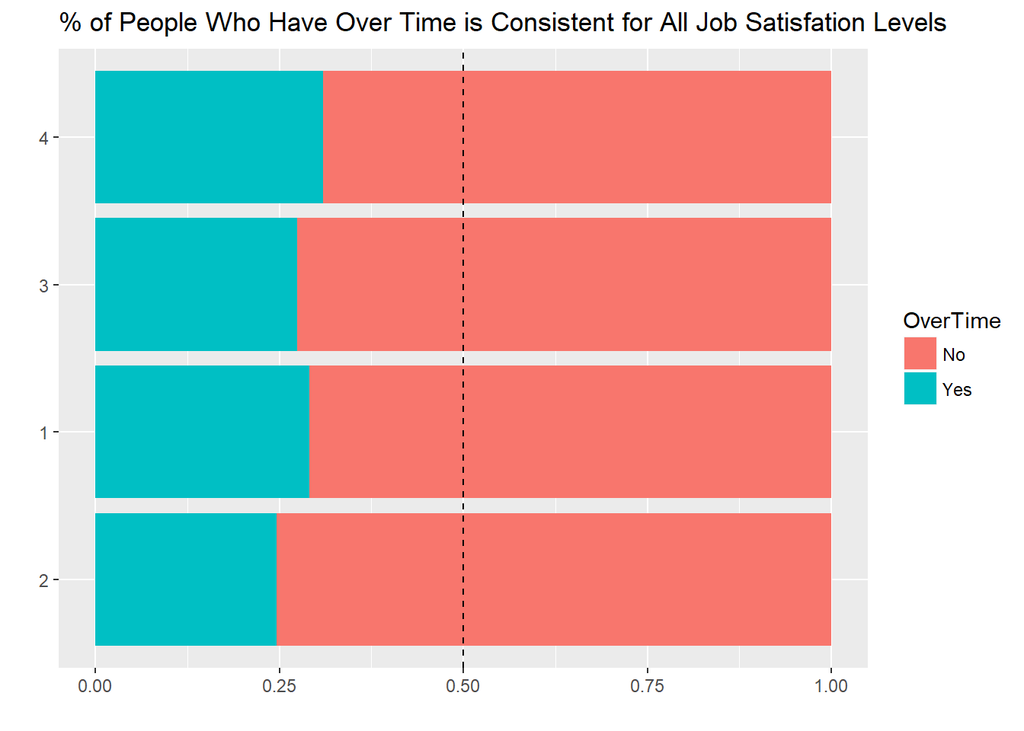

```r
ggplot(data=as.data.frame(table(attrit$JobSatisfaction,attrit$OverTime,dnn=list("JobSatisfaction","OverTime"))), aes(x= reorder(JobSatisfaction,Freq),y=Freq, fill = OverTime)) +
geom_bar(stat="identity",position="fill") + coord_flip() + ggtitle("% of People Who Have Over Time is Consistent for All Job Satisfation Levels") + xlab("") + ylab("") + geom_abline(slope=0, intercept=0.5,  col = "black",lty=2)
```

##### Marital Status

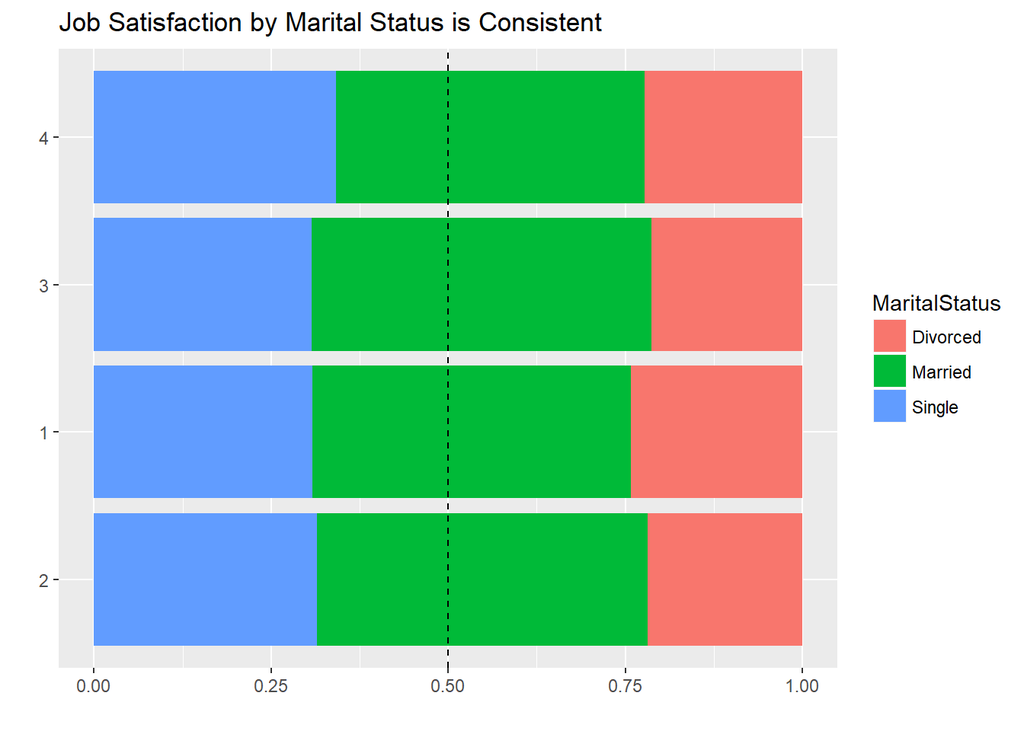

```r
ggplot(data=as.data.frame(table(attrit$JobSatisfaction,attrit$MaritalStatus,dnn=list("JobSatisfaction","MaritalStatus"))), aes(x= reorder(JobSatisfaction,Freq),y=Freq, fill = MaritalStatus)) +
geom_bar(stat="identity",position="fill") + coord_flip() + ggtitle("Job Satisfaction by Marital Status is Consistent") + xlab("") + ylab("") + geom_abline(slope=0, intercept=0.5,  col = "black",lty=2)
```

##### Relationship Satisfaction

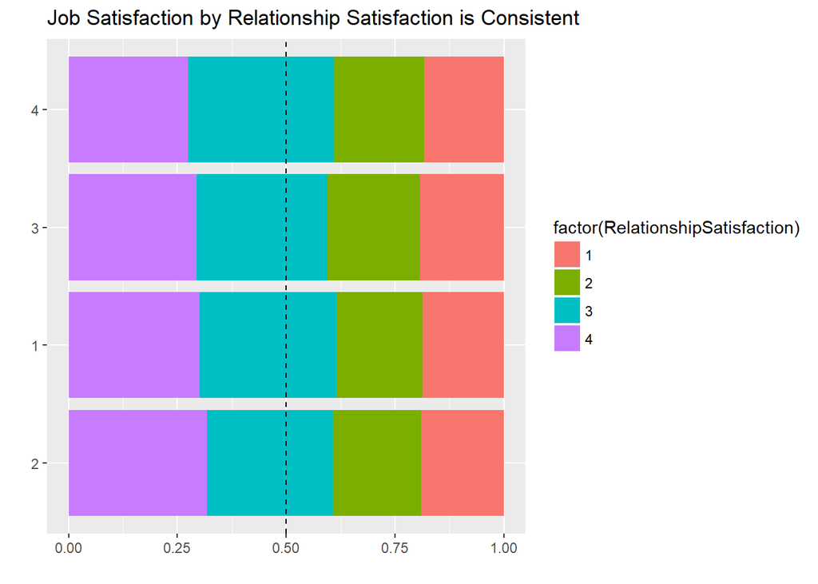

```r
ggplot(data=as.data.frame(table(attrit$JobSatisfaction,attrit$RelationshipSatisfaction,dnn=list("JobSatisfaction","RelationshipSatisfaction"))), aes(x= reorder(JobSatisfaction,Freq),y=Freq, fill = factor(RelationshipSatisfaction))) +
geom_bar(stat="identity",position="fill") + coord_flip() + ggtitle("Job Satisfaction by Relationship Satisfaction is Consistent") + xlab("") + ylab("") + geom_abline(slope=0, intercept=0.5,  col = "black",lty=2)
```

##### Find common demographics for people with high/lo job satisfaction

```r
JS.4 <- noattrit[noattrit$JobSatisfaction==4,]
JS.3 <- noattrit[noattrit$JobSatisfaction==3,]
highjs <- rbind(JS.3, JS.4)
demohighjs<- highjs[1:8]
demohighjs$Attrition <- NULL
demohighjs$BusinessTravel <- NULL
demohighjs$OverTime <- NULL
demohighjs$MaritalStatus <- NULL
countdemohighjs<- count(demohighjs)
head(countdemohighjs[order(countdemohighjs$freq,decreasing = TRUE),],10)
```

```
##                Department EducationField Gender                   JobRole freq
## 21 Research & Development  Life Sciences   Male        Research Scientist   53
## 60                  Sales  Life Sciences   Male           Sales Executive   39
## 17 Research & Development  Life Sciences   Male     Laboratory Technician   38
## 33 Research & Development        Medical   Male        Research Scientist   35
## 16 Research & Development  Life Sciences   Male Healthcare Representative   31
## 66                  Sales      Marketing   Male           Sales Executive   30
## 29 Research & Development        Medical   Male     Laboratory Technician   29
## 15 Research & Development  Life Sciences Female        Research Scientist   28
## 57                  Sales  Life Sciences Female           Sales Executive   25
## 63                  Sales      Marketing Female           Sales Executive   24
```

#### Visual inspection of the Top 10 common demographics suggests exoloring Department, Education Field, Gender and Job Role as factors related to Job Satisfaction

==